# Stable Isotope Mixing Models for Dietary Reconstruction

Module 4 · Three Worked Examples in ReSources · Afternoon Session

Author

Archaeological Isotope Laboratory

Published

20 February 2026

One-Day Training Programme | Afternoon Practical Session

# 1 Three Worked Examples: Progressive Complexity

This module presents **three progressively more complex examples** that illustrate how to build mixing models in ReSources, from the simplest case to a full routed model. Each example adds new features:

**Example 1: The Absolute Simplest Case**  
→ 1 consumer, 2 sources, 1 isotope proxy (δ<sup>13</sup>C only)  
→ No components, no concentrations, no offsets  
→ **Duration:** ~2 minutes to set up and run  
→ **Learning goal:** Understand the basic mixing equation

**Example 2: Adding Realism with Two Isotopes**  
→ 1 consumer, 2 sources, 2 isotope proxies (δ<sup>13</sup>C + δ<sup>15</sup>N)  
→ Trophic enrichment factors (offsets)  
→ Protein concentrations  
→ **Duration:** ~3 minutes  
→ **Learning goal:** Account for isotopic fractionation and nutrient density

**Example 3: Full Routed Model**  
→ 1 consumer, 2 sources, 2 isotope proxies  
→ **Components** (protein vs. carbs/lipids) with differential routing  
→ Concentrations for both components  
→ **Duration:** ~5 minutes  
→ **Learning goal:** Implement selective routing for bone collagen

**Before you begin**

Download the example files from:  
**https://github.com/Pandora-IsoMemo/Support-files**

Files needed:

- `Examples.xls` — contains all three examples’ data
- `Examples.pdf` — visual summary of the examples

# 2 Example 1: One Consumer, Two Sources, One Isotope

## 2.1 Scenario

We have the **simplest possible mixing model**:

- **1 consumer (target)** with bone collagen measured for carbon isotopes
- **2 dietary sources** that also have carbon isotope measurements
- **Goal:** Estimate what proportion of Source 1 vs. Source 2 the consumer ate

**Data for Example 1**

**Consumer:**

- δ<sup>13</sup>C = −15.0 (±0.5) ‰

**Sources:**

- Source 1: δ<sup>13</sup>C = −20.0 (±1.0) ‰
- Source 2: δ<sup>13</sup>C = −10.0 (±1.0) ‰

**Model options:**

- ✗ No components (assuming bulk diet mixing)
- ✗ No concentrations (assuming equal nutrient density)
- ✗ No offsets (assuming no trophic fractionation)

### 2.1.1 Why This is Unrealistic (But Pedagogically Useful)

In real archaeology, **you should always include offsets** (trophic enrichment factors) because bone collagen is isotopically enriched relative to diet. However, starting with zero offsets helps you understand the core mixing equation without complications.

## 2.2 Setting Up Example 1 in ReSources

### 2.2.1 Step 1: Launch ReSources and Configure Model Options

```r
library(ReSources)
ReSources_GUI()
```

**Navigate to:** Core Model Options

**Select:**

- Model type: **“Update model”** (used for averaging across multiple consumers, but works fine for single consumers too)
- Components: **UNCHECK** “Include components”
- Concentrations: **UNCHECK** “Include concentrations”
- Target offset: **UNCHECK** “Include target offset” (this removes the TEF table)

### 2.2.2 Step 2: Enter Consumer Data

**Navigate to:** Data → Target

**Method 1 — Copy-paste from Excel:**

1. Open `Examples.xls` → Sheet “Example 1”
2. Select cells containing: `d13C | target1 | -15 | 0.5` (include header row)
3. Copy (Ctrl+C)
4. In ReSources, click **outside** the Target table (to focus it)
5. Paste (Ctrl+V)

**Method 2 — Manual entry:**

| Column | Value |
| --- | --- |
| **Proxy name** (header) | d13C |
| **Individual** | target1 |
| **Mean** | -15.0 |
| **SD** | 0.5 |

**Critical: Proxy names must match exactly**

The header “d13C” must be **identical** across:

- Target table
- Sources table
- Any other tables referencing this proxy

If names don’t match, ReSources will issue an error and refuse to run.

### 2.2.3 Step 3: Enter Source Data

**Navigate to:** Data → Sources → **d13C tab**

**Copy-paste from Excel:**

1. Select: `Source1 | -20 | 1` and `Source2 | -10 | 1` (with header “d13C”)
2. Copy → Click outside table → Paste (Ctrl+V)

**Manual entry:**

| Source | Mean | SD |
| --- | --- | --- |
| Source1 | -20.0 | 1.0 |
| Source2 | -10.0 | 1.0 |

### 2.2.4 Step 4: Verify No Offsets

**Navigate to:** Data → Target to Source Offset

**Expected:** Table should be **empty** or show offset = 0 (since we unchecked “Include target offset”)

If you see values here, go back to Core Model Options and uncheck the offset option.

### 2.2.5 Step 5: Run the Model

**Click:** “Run Model” button (usually at top of interface)

**Wait for:**

1. **Compilation** (~10–30 seconds) — JAGS converts model specification to executable code
2. **Sampling** (~20–40 seconds) — MCMC runs 50,000 iterations × 3 chains

**Total time:** ~1 minute

**Why is ReSources slower than FRUITS for simple models?**

**Compilation overhead:** ReSources uses JAGS, which requires a compilation step before sampling. FRUITS uses WinBUGS, which doesn’t.

**When ReSources is faster:** For complex models (many consumers, covariates, hierarchical structure), ReSources’ sampling is much more efficient, offsetting the compilation cost.

**Rule of thumb:** For ≤10 consumers, FRUITS may be faster. For ≥50 consumers, ReSources is faster.

## 2.3 Interpreting Example 1 Results

### 2.3.1 Viewing Output Plots

**Navigate to:** Results → Results Plots

**Default view:** Source contributions

**What you see:**

- Two boxplots (one for Source1, one for Source2)
- **Box** = 68% credible interval
- **Whiskers** = 95% credible interval
- **Solid line inside box** = mean
- **Dashed line** = median (hard to see when overlapping with mean)

### 2.3.2 Expected Results

Table 1: Example 1 expected posterior estimates

| Source | Mean | 95% CI | Interpretation |
| --- | --- | --- | --- |
| Source1 | 0.50 | [0.38, 0.62] | 50% contribution (consumer sits halfway between sources) |
| Source2 | 0.50 | [0.38, 0.62] | 50% contribution |

### 2.3.3 The Algebra Behind It

This is a **determined system** (1 tracer, 2 sources → unique solution). The mixing equation is:

$$\delta^{13}C_{\text{consumer}} = f_1 \cdot \delta^{13}C_{\text{Source1}} + f_2 \cdot \delta^{13}C_{\text{Source2}}$$

$$f_1 + f_2 = 1$$

Substituting values:

$$\begin{aligned}
-15 &= f_1 \cdot (-20) + f_2 \cdot (-10) \\
-15 &= f_1 \cdot (-20) + (1 - f_1) \cdot (-10) \\
-15 &= -20f_1 - 10 + 10f_1 \\
-5 &= -10f_1 \\
f_1 &= 0.5
\end{aligned}$$

**Result:** Consumer ate 50% Source 1 and 50% Source 2.

### 2.3.4 Why Use Bayesian Inference for Such a Simple Case?

The algebraic solution (50/50) assumes **no uncertainty**. ReSources propagates measurement error:

- Consumer: ±0.5 ‰
- Source 1: ±1.0 ‰
- Source 2: ±1.0 ‰

This produces the **95% CI [0.38, 0.62]** — a ±12% uncertainty range around the 50% estimate.

## 2.4 Key Lessons from Example 1

**What we learned**

1. **Consumer position determines proportions:** Sitting halfway between sources → 50/50 split
2. **Measurement error propagates:** The ±1 ‰ SDs in sources cause ±12% uncertainty in diet
3. **Bayesian inference quantifies uncertainty:** Even simple models benefit from formal error propagation
4. **This model is unrealistic:** Real bone collagen requires offsets to account for trophic fractionation

# 3 Example 2: Adding Nitrogen and Concentrations

## 3.1 Scenario

1. **A second isotope tracer** (δ<sup>15</sup>N) → improves source discrimination
2. **Trophic enrichment factors** (offsets) → accounts for isotopic fractionation
3. **Protein concentrations** → adjusts for different nutrient densities

**Data for Example 2**

**Consumer:**

- δ<sup>13</sup>C = −9.0 (±0.5) ‰
- δ<sup>15</sup>N = +13.0 (±0.5) ‰

**Sources:**

| Source | δ¹³C (‰) | δ¹⁵N (‰) | Protein (%) |
| --- | --- | --- | --- |
| Source 1 | −20.0 (±1.0) | +5.0 (±1.0) | 20 (±5) |
| Source 2 | −10.0 (±1.0) | +10.0 (±1.0) | 40 (±5) |

**Offsets:**

- Δ<sup>13</sup>C = +1.0 (±0.5) ‰
- Δ<sup>15</sup>N = +5.5 (±0.5) ‰

**Model options:**

- ✗ No components (still assuming bulk diet, not routed)
- ✓ **Include concentrations**
- ✓ **Include offsets**

## 3.2 Why These Features Matter

### 3.2.1 Trophic Enrichment Factors (Offsets)

When a consumer eats a food source, **isotopic fractionation** occurs during digestion, metabolism, and tissue synthesis. The consumer’s tissue is systematically enriched in heavy isotopes relative to diet:

- Δ<sup>13</sup>C ≈ +1 ‰ (carbon fractionation)
- Δ<sup>15</sup>N ≈ +3 to +5 ‰ (nitrogen fractionation)

**Without offsets:** Consumer δ<sup>13</sup>C (−9) and δ<sup>15</sup>N (+13) would seem **incompatible** with sources (δ<sup>13</sup>C: −20, −10; δ<sup>15</sup>N: +5, +10)

**With offsets:** After adding Δ<sup>13</sup>C = +1 and Δ<sup>15</sup>N = +5.5, sources become:

- Source 1 (corrected): δ<sup>13</sup>C = −19 ‰, δ<sup>15</sup>N = +10.5 ‰
- Source 2 (corrected): δ<sup>13</sup>C = −9 ‰, δ<sup>15</sup>N = +15.5 ‰

Now consumer (−9, +13) falls **inside** the mixing space.

### 3.2.2 Protein Concentrations

Different foods have vastly different **protein densities**:

- Source 1: 20% protein
- Source 2: 40% protein

If a consumer eats **equal masses** (1 kg each), they ingest:

- From Source 1: 1 × 20% = **0.2 kg protein**
- From Source 2: 1 × 40% = **0.4 kg protein**

**Protein contribution:**

- Source 1: 0.2 / 0.6 = **33%**
- Source 2: 0.4 / 0.6 = **67%**

Concentrations adjust the model to estimate **nutrient intake**, not just food mass.

## 3.3 Setting Up Example 2 in ReSources

### 3.3.1 Step 1: Configure Model Options

**Navigate to:** Core Model Options

**Change from Example 1:**

- ✓ **CHECK** “Include concentrations”
- ✓ **CHECK** “Constrain concentrations 0–100”
- ✓ **CHECK** “Include target offset” (this restores the TEF table)
- Components: still **UNCHECKED**

### 3.3.2 Step 2: Enter Consumer Data (Two Isotopes)

**Navigate to:** Data → Target

**Copy from Example 2 sheet:**

| Proxy | d13C | d15N |
| --- | --- | --- |
| **target1 (mean)** | -9.0 | 13.0 |
| **target1 (SD)** | 0.5 | 0.5 |

Or select the row in Excel including both proxies, copy, and paste into ReSources.

### 3.3.3 Step 3: Enter Trophic Enrichment Factors

**Navigate to:** Data → Target to Source Offset

**Enter:**

| Proxy | Offset (mean) | Offset (SD) |
| --- | --- | --- |
| d13C | +1.0 | 0.5 |
| d15N | +5.5 | 0.5 |

**Method:** Copy these two rows from Excel Example 2 → Click outside table → Ctrl+V

### 3.3.4 Step 4: Enter Source Data (Two Isotopes)

**Navigate to:** Data → Sources

**For d13C tab:**

| Source | Mean | SD |
| --- | --- | --- |
| Source1 | -20.0 | 1.0 |
| Source2 | -10.0 | 1.0 |

**For d15N tab:**

| Source | Mean | SD |
| --- | --- | --- |
| Source1 | 5.0 | 1.0 |
| Source2 | 10.0 | 1.0 |

**Note:** You must enter each proxy separately when you have multiple isotopes.

### 3.3.5 Step 5: Enter Concentrations

**Navigate to:** Data → Concentrations

**Enter:**

Because we haven’t enabled components, we only have the **default concentration** (interpreted as protein):

| Source | d13C (mean) | d13C (SD) | d15N (mean) | d15N (SD) |
| --- | --- | --- | --- | --- |
| Source1 | 20.0 | 5.0 | 20.0 | 5.0 |
| Source2 | 40.0 | 5.0 | 40.0 | 5.0 |

**Interpretation:** Source 1 has 20% protein, Source 2 has 40% protein (by dry weight).

⚠️ **Note:** The values for d13C and d15N concentrations are the same because we’re measuring the same nutrient (protein) — the table just asks separately for each proxy.

### 3.3.6 Step 6: Run the Model

**Click:** “Run Model”

**Wait:** ~1–2 minutes (slightly longer than Example 1 due to added complexity)

## 3.4 Interpreting Example 2 Results

### 3.4.1 Viewing Results

**Navigate to:** Results → Results Plots

**Select estimate type:** “Source contributions” (default)

**Display:** Boxplots for Source1 and Source2

### 3.4.2 Expected Posterior Estimates

Table 2: Example 2 expected results

| Source | Mean | 95% CI | Interpretation |
| --- | --- | --- | --- |
| Source1 | 0.30 | [0.18, 0.44] | ~30% contribution (lower protein density) |
| Source2 | 0.70 | [0.56, 0.82] | ~70% contribution (higher protein density + closer isotope match) |

### 3.4.3 Why Source 2 Dominates

1. **Carbon match:** After offset correction (−10 + 1 = −9), Source 2’s δ<sup>13</sup>C **exactly matches** consumer (−9)
2. **Nitrogen proximity:** Consumer δ<sup>15</sup>N (+13) is closer to Source 2 (corrected +15.5) than Source 1 (+10.5)
3. **Higher protein density:** Source 2 (40% protein) contributes more protein per gram than Source 1 (20%)

### 3.4.4 Comparing Estimate Types

ReSources provides multiple estimate types. Let’s explore them:

**Navigate to:** Results → Results Plots

**Select different estimate types:**

1. **Source contributions** — Overall contribution to diet (what we’ve been looking at)
2. **Source contributions by d13C** — How much of the carbon signal comes from each source
3. **Source contributions by d15N** — How much of the nitrogen signal comes from each source

In Example 2, these three estimates will be **similar but not identical** because:

- Consumer sits at different relative positions in carbon vs. nitrogen space
- Concentrations affect how bulk food mass translates to nutrient contribution

## 3.5 Sensitivity Check: What if We Forgot Offsets?

Let’s see what happens if we **incorrectly set offsets to zero**:

### 3.5.1 Scenario: Offsets = 0 (Wrong!)

Consumer: δ<sup>13</sup>C = −9 ‰, δ<sup>15</sup>N = +13 ‰

Raw sources (no offset):

- Source 1: δ<sup>13</sup>C = −20 ‰, δ<sup>15</sup>N = +5 ‰
- Source 2: δ<sup>13</sup>C = −10 ‰, δ<sup>15</sup>N = +10 ‰

**Problem:** Consumer δ<sup>15</sup>N (+13) is **higher** than both sources (+5, +10). This is **impossible** in a two-source mixing model without enrichment.

**ReSources will:**

1. Issue a warning: “Consumer values outside mixing space”
2. Possibly fail convergence
3. Return extreme posterior estimates (e.g., >100% or negative proportions)

**Always include offsets for bone collagen**

Trophic enrichment is a **physical phenomenon**. Omitting offsets produces nonsensical results. Always include TEFs based on:

- Controlled feeding experiments (preferred)
- Literature values for similar tissues/species
- Sensitivity analyses with multiple TEF estimates

## 3.6 Key Lessons from Example 2

**What we learned**

1. **Two isotopes dramatically improve resolution:** δ<sup>15</sup>N distinguishes sources that have similar δ<sup>13</sup>C
2. **Offsets are non-negotiable:** Without TEFs, consumer values are incompatible with sources
3. **Concentrations matter:** A source with 40% protein contributes more to collagen nitrogen than one with 20%, even if eaten in equal mass
4. **Multiple estimate types provide different insights:** “Source contributions” ≠ “Contributions by nitrogen” when concentrations vary

# 4 Example 3: Full Routed Mixing Model

## 4.1 Scenario

Now we implement the **complete routed mixing model** that accounts for:

- **Selective routing** of dietary protein vs. energy (carbs/lipids) to bone collagen
- **Different isotope values** for protein vs. energy within each source
- **Concentrations** for both components

This is the **gold standard** for bone collagen dietary reconstruction.

**Data for Example 3**

**Consumer (same as Example 2):**

- δ<sup>13</sup>C = −9.0 (±0.5) ‰
- δ<sup>15</sup>N = +13.0 (±0.5) ‰

**Sources (component-specific):**

| Source | δ¹³C protein | δ¹³C carbs/lipids | δ¹⁵N protein |
| --- | --- | --- | --- |
| Source 1 | −20 (±1) | −19 (±1) | +5 (±1) |
| Source 2 | −10 (±1) | −11 (±1) | +10 (±1) |

**Concentrations:**

| Source | Protein (%) | Carbs/lipids (%) |
| --- | --- | --- |
| Source 1 | 20 (±5) | 60 (±5) |
| Source 2 | 40 (±5) | 40 (±5) |

**Component weights (routing):**

- δ<sup>13</sup>C collagen: **74% from protein**, 26% from energy
- δ<sup>15</sup>N collagen: **100% from protein**, 0% from energy

**Offsets:**

- Δ<sup>13</sup>C = **+4.0** (±0.5) ‰ [Note: different from Example 2!]
- Δ<sup>15</sup>N = +5.5 (±0.5) ‰

## 4.2 Why Routing Matters: The Fundamental Insight

Bone collagen is **not** a simple average of bulk diet isotope values. It is a **protein-specific tissue** whose carbon is derived:

- ~74% from dietary **protein** (amino acids)
- ~26% from dietary **energy** (carbs/lipids, via gluconeogenesis)

This was established by controlled feeding experiments (Ambrose & Norr 1993, Jim et al. 2006).

### 4.2.1 Real-World Consequence

Imagine a population eating:

- **70% maize by calories** (C<sub>4</sub> plant, δ<sup>13</sup>C ≈ −12 ‰) — provides energy
- **30% animal meat** (δ<sup>13</sup>C ≈ −21 ‰) — provides protein

**Unrouted model** (Example 2) would predict:

$$\delta^{13}C_{\text{collagen}} = 0.70 \times (-12) + 0.30 \times (-21) = -14.7 \text{ ‰}$$

**Routed model** (Example 3) with λ = 0.74:

$$\begin{aligned}
\delta^{13}C_{\text{collagen}} &= 0.74 \times (\text{protein C}) + 0.26 \times (\text{energy C}) \\
&= 0.74 \times (-21) + 0.26 \times (-12) \\
&= -18.7 \text{ ‰}
\end{aligned}$$

**Difference: 4 ‰** — enough to completely change dietary interpretation!

## 4.3 Setting Up Example 3 in ReSources

### 4.3.1 Step 1: Enable Components

**Navigate to:** Core Model Options

**Critical change:**

- ✓ **CHECK** “Include components”

**Keep enabled:**

- ✓ Include concentrations
- ✓ Include target offset

This unlocks the **Components table** where we define routing weights.

### 4.3.2 Step 2: Enter Consumer Data (No Change)

**Navigate to:** Data → Target

Consumer values are the **same** as Example 2:

| Proxy | d13C | d15N |
| --- | --- | --- |
| target1 (mean) | -9.0 | 13.0 |
| target1 (SD) | 0.5 | 0.5 |

### 4.3.3 Step 3: Update Offsets

**Navigate to:** Data → Target to Source Offset

**Note the change** in carbon offset:

| Proxy | Offset (mean) | Offset (SD) |
| --- | --- | --- |
| d13C | **+4.0** | 0.5 |
| d15N | +5.5 | 0.5 |

⚠️ **Why higher carbon offset?** This example uses a different TEF convention. Always match your TEF values to your routing parameterization.

### 4.3.4 Step 4: Define Component Weights (NEW!)

**Navigate to:** Data → Components

This table defines **how much of the collagen signal** comes from each dietary component.

**Enter:**

| Proxy | Protein (mean) | Protein (SD) | CarbsLipids (mean) | CarbsLipids (SD) |
| --- | --- | --- | --- | --- |
| d13C | 0.74 | 0.00 | 0.26 | 0.00 |
| d15N | 1.00 | 0.00 | 0.00 | 0.00 |

**Interpretation:**

- **d13C row:** 74% of collagen carbon from protein, 26% from carbs/lipids
- **d15N row:** 100% of collagen nitrogen from protein, 0% from energy (no N in carbs/lipids)

⚠️ **Critical:** Component names (“Protein”, “CarbsLipids”) must **exactly match** across:

- This Components table
- The Sources tables (next step)
- The Concentrations table

### 4.3.5 Step 5: Enter Component-Specific Source Data

When components are enabled, the **Sources table structure changes**. You must now enter isotope values **separately for each component**.

**Navigate to:** Data → Sources → **d13C tab**

Notice the table now has columns for **Protein** and **CarbsLipids**:

| Source | Protein (mean) | Protein (SD) | CarbsLipids (mean) | CarbsLipids (SD) |
| --- | --- | --- | --- | --- |
| Source1 | -20.0 | 1.0 | -19.0 | 1.0 |
| Source2 | -10.0 | 1.0 | -11.0 | 1.0 |

**Interpretation:** Source 1 has protein with δ<sup>13</sup>C = −20 ‰ and carbs/lipids with δ<sup>13</sup>C = −19 ‰.

**Navigate to:** Data → Sources → **d15N tab**

Nitrogen only has one component (protein) because there’s essentially no nitrogen in carbs/lipids:

| Source | Protein (mean) | Protein (SD) |
| --- | --- | --- |
| Source1 | 5.0 | 1.0 |
| Source2 | 10.0 | 1.0 |

### 4.3.6 Step 6: Enter Component-Specific Concentrations

**Navigate to:** Data → Concentrations

Now we enter concentrations for **both** components:

| Source | Protein (mean) | Protein (SD) | CarbsLipids (mean) | CarbsLipids (SD) |
| --- | --- | --- | --- | --- |
| Source1 | 20.0 | 5.0 | 60.0 | 5.0 |
| Source2 | 40.0 | 5.0 | 40.0 | 5.0 |

**Interpretation:**

- Source 1: 20% protein, 60% carbs/lipids (+ 20% other = 100%)
- Source 2: 40% protein, 40% carbs/lipids (+ 20% other = 100%)

### 4.3.7 Step 7: Final Check

**Checklist before running:**

✓ Components table: Protein = 0.74, CarbsLipids = 0.26 for d13C  
✓ Sources d13C: Both Protein and CarbsLipids columns filled  
✓ Sources d15N: Only Protein column (no CarbsLipids)  
✓ Concentrations: Both components entered  
✓ Offsets: d13C = +4.0, d15N = +5.5

**Common mistake:** Forgetting to update Sources tables when components are enabled. If you see missing data errors, check that component columns match the names in the Components table.

### 4.3.8 Step 8: Run the Model

**Click:** “Run Model”

**Wait:** ~1–3 minutes (slightly longer due to routing complexity)

**Check for warnings:** ReSources will flag any naming mismatches between tables

## 4.4 Interpreting Example 3 Results

### 4.4.1 New Estimate Type: Component Contributions

Example 3 introduces a **new estimate** not available in Examples 1–2:

**Navigate to:** Results → Results Plots

**Select estimate type:** “Component contributions”

**What you see:**

- Boxplot for **Protein**
- Boxplot for **CarbsLipids**

**Interpretation:** Of the total nutrients consumed, what % were protein vs. carbs/lipids?

### 4.4.2 Expected Results

Table 3: Example 3 expected results

| Estimate type | Source/Component | Mean | 95% CI |
| --- | --- | --- | --- |
| **Source contributions** | Source1 | 0.35 | [0.21, 0.50] |
|  | Source2 | 0.65 | [0.50, 0.79] |
| **Source contributions by d15N** | Source1 | 0.35 | [0.21, 0.50] |
| *(protein only)* | Source2 | 0.65 | [0.50, 0.79] |
| **Source contributions by d13C** | Source1 | 0.32 | [0.18, 0.47] |
| *(mixed protein + energy)* | Source2 | 0.68 | [0.53, 0.82] |
| **Component contributions** | Protein | 0.45 | [0.38, 0.52] |
|  | CarbsLipids | 0.55 | [0.48, 0.62] |

### 4.4.3 Understanding the Different Estimates

1. **Source contributions** — Overall dietary contribution from each source (adjusted for concentrations of all components)
2. **Source contributions by d15N** — Since N is 100% from protein, this tells us **protein source contributions**
3. **Source contributions by d13C** — Carbon comes from both protein (74%) and energy (26%), so this is a **weighted mixture**
4. **Component contributions** — Of total macronutrients consumed, 45% were protein and 55% were carbs/lipids

**Key insight from component contributions**

If you want to know **how much protein** came from each source, look at:

- **“Source contributions by d15N”** — nitrogen is 100% protein-derived

This is **not the same** as “source contributions” which includes all nutrients.

## 4.5 Comparing Example 2 vs. Example 3

Let’s directly compare the **unrouted** (Example 2) vs. **routed** (Example 3) models:

Table 4: Comparison of unrouted vs. routed models

| Feature | Example 2 (Unrouted) | Example 3 (Routed) |
| --- | --- | --- |
| **Assumes:** | Bulk diet mixing | Protein-selective routing |
| **Source 2 contribution** | ~70% | ~65% |
| **Estimate stability** | Single “source contribution” | Separate protein vs. total estimates |
| **Carbon offset** | +1.0 ‰ | +4.0 ‰ (different TEF convention) |
| **Best for:** | Tissues with bulk mixing | Bone/dentine collagen |

**Key difference:** Routed models provide **more information**:

- Component contributions (protein vs. energy balance)
- Separate protein source estimates (via nitrogen)
- Better match to controlled-diet experiments

## 4.6 Visualizing the Routing Concept

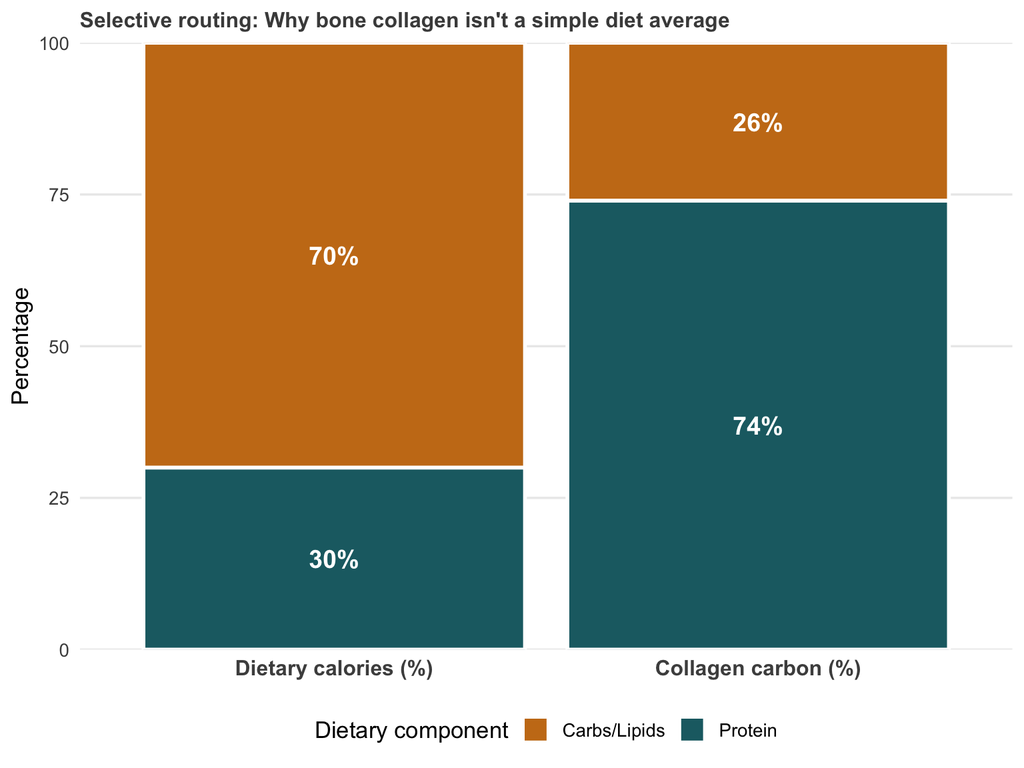

Figure 1: Selective routing in bone collagen synthesis. Dietary protein dominates collagen carbon (74%) despite potentially being a minority of calories.

**Interpretation:** A diet that is 70% carbs/lipids by calories produces bone collagen that is only 26% energy-derived carbon. Protein dominates the signal despite being a caloric minority.

## 4.7 Key Lessons from Example 3

**What we learned**

1. **Routing is essential for bone collagen:** Unrouted models systematically misestimate protein contributions
2. **Component contributions provide new insights:** You can now quantify the **protein vs. energy balance** of the diet, not just food sources
3. **Nitrogen estimates = protein estimates:** Since N is 100% protein-derived, “Source contributions by d15N” directly tells you protein source contributions
4. **More data entry, more information:** Routed models require component-specific source values and concentrations, but they return richer dietary reconstructions
5. **This is the gold standard for archaeological collagen analysis:** Always use routed models (ReSources, FRUITS) for bone/dentine collagen studies

# 5 Summary Comparison of All Three Examples

Table 5: Comparison of the three examples

| Feature | Example 1 | Example 2 | Example 3 |
| --- | --- | --- | --- |
| **Consumers** | 1 | 1 | 1 |
| **Sources** | 2 | 2 | 2 |
| **Isotope proxies** | 1 (δ<sup>13</sup>C) | 2 (δ<sup>13</sup>C, δ<sup>15</sup>N) | 2 (δ<sup>13</sup>C, δ<sup>15</sup>N) |
| **Components** | No | No | **Yes** (Protein, CarbsLipids) |
| **Concentrations** | No | Yes | Yes (both components) |
| **Offsets** | No (0 ‰) | Yes (+1, +5.5 ‰) | Yes (+4, +5.5 ‰) |
| **Setup time** | 2 min | 3 min | 5 min |
| **Run time** | 1 min | 1–2 min | 2–3 min |
| **Result type** | Source contributions | Source contributions + by-proxy | + Component contributions |
| **Realism** | Pedagogical only | Moderate | High (gold standard) |
| **Use in archaeology** | Never | Acceptable for non-collagen tissues | **Always for bone collagen** |

# 6 Practical Tips and Common Errors

## 6.1 Data Entry Best Practices

### 6.1.1 Copy-Paste Workflow

**Efficient workflow:**

1. Prepare all data in **one Excel sheet** with clearly labeled sections
2. Always **include header rows** when copying (proxy names, component names)
3. **Click outside** the ReSources table before pasting (Ctrl+V)
4. If paste doesn’t work, try clicking the “Paste” button instead of Ctrl+V
5. **Verify immediately** after pasting — check that values and names are correct

### 6.1.2 Naming Conventions

**Critical: Names must match exactly**

**These names must be identical across tables:**

- **Proxy names** (e.g., “d13C”, “d15N”) in:
  - Target table headers
  - Sources table tabs
  - Components table rows
  - Offsets table rows
- **Component names** (e.g., “Protein”, “CarbsLipids”) in:
  - Components table headers
  - Sources table headers
  - Concentrations table headers

**Common errors:**

- “protein” vs. “Protein” (case matters!)
- “d13C” vs. “d 13C” (spaces matter!)
- “CarbsLipids” vs. “Carbs/Lipids” (slashes/underscores matter!)

## 6.2 Troubleshooting Common Errors

### 6.2.1 Error: “Proxy names do not match”

**Cause:** Header name in Target table doesn’t match tab name in Sources

**Fix:** Check spelling, capitalization, and spacing in both tables

### 6.2.2 Error: “Component names not found”

**Cause:** Component names in Components table don’t match Sources table headers

**Fix:** Ensure “Protein”, “CarbsLipids” (or your chosen names) are spelled identically

### 6.2.3 Error: “Consumer outside mixing space”

**Cause:**

1. Offsets are missing or incorrect
2. Sources don’t span the consumer isotope values

**Fix:**

- If you forgot offsets: Add them (TEFs) to Target to Source Offset table
- If sources don’t cover consumer: Check for missing dietary sources or measurement errors

### 6.2.4 Model runs but gives nonsensical results (e.g., >100% or negative)

**Cause:** Severe data inconsistency or convergence failure

**Fix:**

1. Check **Results → Diagnostics → Convergence** — look for failed parameters
2. Increase MCMC iterations (try 100,000 instead of 50,000)
3. Check for typos in data entry
4. Verify that consumer falls within or near source mixing space using **Model Characteristics → Source-Mixture Plot**

# 7 Advanced: Interpreting Convergence Diagnostics

## 7.1 Gelman-Rubin Statistic ($\hat{R}$)

After running the model, ReSources reports convergence for each parameter:

**Navigate to:** Results → Model Summary (or check the post-run message)

**If failures reported:**

- $\hat{R} > 1.1$ for some parameters → chains haven’t mixed properly
- **Action:** Increase iterations to 100,000 or 200,000

## 7.2 Trace Plots

**Navigate to:** Results → Diagnostics → Trace Plots

**Select:** “Source contributions” → “Source1” → “target1”

**What to look for:**

✓ **“Hairy caterpillar”** — rapid up-and-down mixing, all 3 chains overlap  
✗ **Trending upward/downward** — chain still burning in (increase burn-in)  
✗ **Chains separate** — poor mixing (increase iterations or check data)

# 8 Learning Outcomes Checklist

By the end of this module you should be able to:

# 9 Next Steps: Applying to Your Data

## 9.1 Preparing Your Archaeological Dataset

**Checklist for real-world analysis:**

1. **Collagen quality screening:**
   - C:N ratios: 2.9–3.6 (DeNiro criterion)
   - %C: 30–45%, %N: 11–16%
   - Exclude degraded specimens
2. **Source reference data:**
   - n ≥ 10–15 specimens per source
   - Same site/period as consumers
   - Isotopically characterized for all components
3. **TEF justification:**
   - Literature values with uncertainty
   - Conduct sensitivity analyses (vary TEFs ±1 ‰)
   - Document in methods section
4. **Routing parameter:**
   - Use λ = 0.74 ± 0.08 for human bone collagen (default)
   - Consider species-specific values for fauna
   - Report source (Fernandes et al. 2012)
5. **Concentrations:**
   - USDA database for modern analogs
   - Archaeological context-specific estimates where available
   - Propagate uncertainty (use SDs of 20–30% if unknown)

## 9.2 Suggested Exercises

1. **Modify Example 3:** Change consumer isotope values to (−12, +15) and predict which source will dominate before running
2. **Three-source model:** Add a third source to Example 2 and observe how credible intervals widen (underdetermined system)
3. **Sensitivity analysis:** Run Example 3 twice with different routing parameters (λ = 0.70 vs. 0.80) and compare results
4. **Real data:** Input one of your own skeletal assemblages using Example 3 as a template

# 10 Key References

**On ReSources:**

Fernandes, R., Bataille, C.P., Rasigraf, O., Raghavan, M. & Mallick, R. (2021) Assessing the use of bulk stable isotope data in zooarchaeology. *Science Advances*, **7**, eabg5791.

**On routing and controlled diet experiments:**

Ambrose, S.H. & Norr, L. (1993) Experimental evidence for the relationship of the carbon isotope ratios of whole diet and dietary protein to those of bone collagen and carbonate. In: *Prehistoric Human Bone*, pp. 1–37.

Jim, S., Jones, V., Ambrose, S.H. & Evershed, R.P. (2006) Quantifying dietary macronutrient sources of carbon for bone collagen biosynthesis. *British Journal of Nutrition*, **95**, 1055–1062.

Fernandes, R., Nadeau, M.-J. & Grootes, P.M. (2012) Macronutrient-based model for dietary carbon routing in bone collagen and bioapatite. *Archaeological and Anthropological Sciences*, **4**, 291–301.

**On ReSources vs. FRUITS:**

Fernandes, R., Millard, A.R., Brabec, M., Nadeau, M.-J. & Grootes, P. (2014) Food reconstruction using isotopic transferred signals (FRUITS): a Bayesian model for diet reconstruction. *PLoS ONE*, **9**, e87436.

*End of Module 4*

*You have now completed the full one-day training programme in stable isotope mixing models for dietary reconstruction. Congratulations!*